# Statistiek I - Lab session 7

# 4 Exercise 4

```r
# What is the relation between english_score and english_score_self?

# Correlation strength r
cor(full$english_score, full$english_score_self)
```

```
## [1] 0.8255597
```

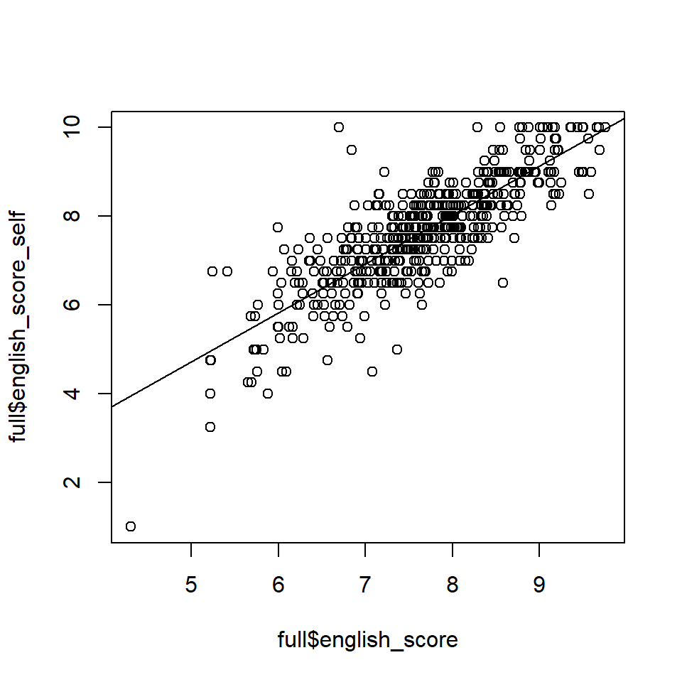

```r
# Visualizing
plot(full$english_score, full$english_score_self)
abline(lm(full$english_score_self ~ full$english_score))
```

There seems to be a strong positive correlation between english_score and english_score_self. As the English score goes up, so does the English score someone would give themselves (and vice versa). This also seems logical, since someone who is good in English and receives a higher score, would also base their self assessment on how good their English is (their score). So, this seems like a logical positive correlation as you would expect someone who was better in English to also assess themselves better.

# 5 Exercise 5

```r
# Is the reliability of both the Difficulty and the Value scale of the SATA acceptable or higher?

# Difficulty: 6, 8*, 22, 24*, 30*, 34*, 36*
# Reliability of Difficulty questions
library(psych)
difficulty <- data.frame(full$Q6, full$Q8, full$Q22, full$Q24, full$Q30, full$Q34, full$Q36)

# Cronbach's a with inverted questions of Reliability questions
result <- alpha(difficulty, keys = c("full.Q8", "full.Q24", "full.Q30", "full.Q34", "full.Q36"))
summary(result)
```

```
##
## Reliability analysis
##  raw_alpha std.alpha G6(smc) average_r S/N   ase mean   sd median_r
##       0.77      0.77    0.77      0.33 3.4 0.015  3.5 0.78     0.33
```

```r
# Checking if dropping a question would improve it.
result$alpha.drop # No, it would not.
```

```
##           raw_alpha std.alpha   G6(smc) average_r      S/N   alpha se
## full.Q6   0.7404787 0.7392466 0.7146528 0.3208860 2.835041 0.01769212
## full.Q8-  0.7101492 0.7137584 0.6857477 0.2935818 2.493552 0.01993088
## full.Q22  0.7611811 0.7609998 0.7480355 0.3466968 3.184097 0.01626581
## full.Q24- 0.7330501 0.7295961 0.7152750 0.3101999 2.698172 0.01802012
## full.Q30- 0.7613259 0.7584746 0.7464954 0.3435701 3.140351 0.01606409
## full.Q34- 0.7565796 0.7542225 0.7413477 0.3383852 3.068720 0.01641992
## full.Q36- 0.7558789 0.7528581 0.7410996 0.3367423 3.046258 0.01654091
##                 var.r     med.r
## full.Q6   0.006462787 0.3285564
## full.Q8-  0.004380786 0.3118202
## full.Q22  0.009859982 0.3295052
## full.Q24- 0.010745156 0.3118202
## full.Q30- 0.011755304 0.3295052
## full.Q34- 0.011356458 0.3295052
## full.Q36- 0.012021921 0.3326898
```

```r
# Cronbach's a is > 0.7, which means it is acceptable. This mean the mean can be used as summary of the scale.

# Inverting columns
difficulty["full.Q8"] <- 8 - difficulty["full.Q8"]
difficulty["full.Q24"] <- 8 - difficulty["full.Q24"]
difficulty["full.Q30"] <- 8 - difficulty["full.Q30"]
difficulty["full.Q34"] <- 8 - difficulty["full.Q34"]
difficulty["full.Q36"] <- 8 - difficulty["full.Q36"]

# Calculating mean and putting it in df 'full'
difficulty$Mean <- rowMeans(difficulty)
full$SATSdifficulty <- difficulty$Mean

# Value: 7*, 9, 10, 13*, 16*, 17, 21*, 25*, 33*
# Reliability of Value questions
value <- data.frame(full$Q7, full$Q9, full$Q10, full$Q13, full$Q16, full$Q17, full$Q21, full$Q25, full$Q33)

# Cronbach's a with inverted questions of Value questions
result <- alpha(value, keys = c("full.Q7", "full.Q13", "full.Q16", "full.Q21", "full.Q25", "full.Q33"))
summary(result)
```

```
##
## Reliability analysis
##  raw_alpha std.alpha G6(smc) average_r S/N   ase mean   sd median_r
##        0.8       0.8    0.81      0.31 4.1 0.014  4.9 0.77     0.33
```

```r
# Checking if dropping a questions would improve it.
result$alpha.drop # Q21 could be dropped, but it wouldn't really improve it at all (only by 0.0015).
```

```
##           raw_alpha std.alpha   G6(smc) average_r      S/N   alpha se
## full.Q7-  0.7741183 0.7802893 0.7803630 0.3074457 3.551440 0.01528129
## full.Q9   0.7799699 0.7873360 0.7832137 0.3163710 3.702254 0.01486388
## full.Q10  0.7654925 0.7736195 0.7716448 0.2993115 3.417342 0.01583978
## full.Q13- 0.7862607 0.7927517 0.7918672 0.3234747 3.825130 0.01443072
## full.Q16- 0.7723624 0.7810322 0.7811150 0.3083702 3.566881 0.01539248
## full.Q17  0.7888353 0.7945071 0.7919480 0.3258246 3.866349 0.01422731
## full.Q21- 0.8015248 0.8082310 0.8056209 0.3450465 4.214607 0.01344251
## full.Q25- 0.7658771 0.7747870 0.7750999 0.3007140 3.440241 0.01586408
## full.Q33- 0.7469422 0.7548406 0.7522462 0.2779118 3.078979 0.01714174
##                var.r     med.r
## full.Q7-  0.01533421 0.3222449
## full.Q9   0.01264553 0.3347653
## full.Q10  0.01437540 0.3088134
## full.Q13- 0.01370633 0.3314027
## full.Q16- 0.01557438 0.3314027
## full.Q17  0.01457771 0.3367479
## full.Q21- 0.01088398 0.3438994
## full.Q25- 0.01422217 0.3222449
## full.Q33- 0.01079788 0.2972506
```

```r
# Cronbach's a is = 0.8, which means it is acceptable and pretty much good.

# Inverting columns
value["full.Q7"] <- 8 - value["full.Q7"]
value["full.Q13"] <- 8 - value["full.Q13"]
value["full.Q16"] <- 8 - value["full.Q16"]
value["full.Q21"] <- 8 - value["full.Q21"]
value["full.Q25"] <- 8 - value["full.Q25"]
value["full.Q33"] <- 8 - value["full.Q33"]

# Calculating mean and putting it in df 'full'
value$Mean <- rowMeans(value)
full$SATSvalue <- value$Mean

# Calculating the correlation between SATSvalue and SATSdifficulty
cor(full$SATSdifficulty, full$SATSvalue)
```

```
## [1] 0.3231681
```

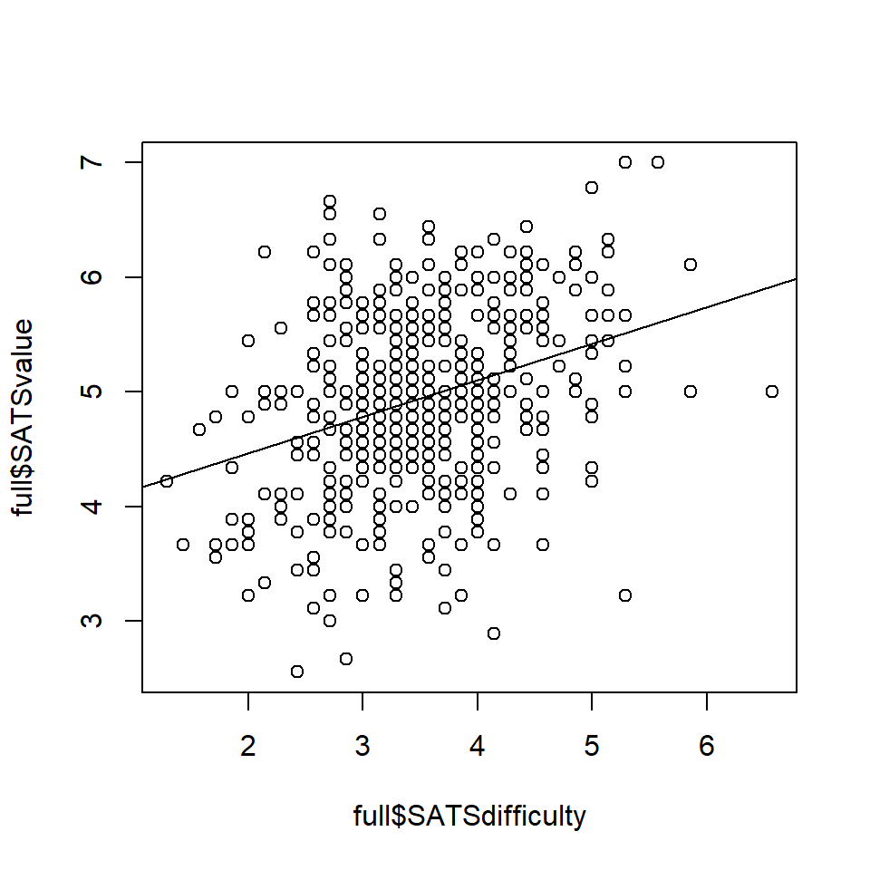

```r
#Plotting the correlation
plot(full$SATSdifficulty, full$SATSvalue)
abline(lm(full$SATSvalue ~ full$SATSdifficulty))
```

```r
# There is a positive correlation between SATSdifficulty and SATSvalue questions. It seems that students that as students give higher answers on one of the type of questions, they also do so on the other. Also, the value questions are given a higher grade on average in comparison difficulty questions.
```